# Statistical inference with the GSS data

## Table of Contents

1. 1. Data
2. 2. Research Question
3. 3. EDA
4. 4. Inference
5. 4.1 Hypothesis
6. 4.2 Conditions
7. 4.3 Method to do inference
8. 4.4 Inference
9. 4.5 Confidence Interval
10. 4.6 Result/Conclusion

### Load packages

```r
library(ggplot2)
library(dplyr)
library(statsr)
```

### Load data

```r
load("gss.Rdata")
```

## Part 1: Data

Since 1972, the General Social Survey (GSS) has been monitoring societal change and studying the growing complexity of American society. The GSS aims to gather data on contemporary American society in order to monitor and explain trends and constants in attitudes, behaviors, and attributes; to examine the structure and functioning of society in general as well as the role played by relevant subgroups; to compare the United States to other societies in order to place American society in comparative perspective and develop cross-national models of human society; and to make high-quality data easily accessible to scholars, students, policy makers, and others, with minimal cost and waiting.

GSS questions include such items as national spending priorities, marijuana use, crime and punishment, race relations, quality of life, and confidence in institutions.

Since this survey is done by random sampling and the results can be “**generalized**” but not “causality” due to no random assignment.

## Part 2: Research question

As the survey concentrates in studying the complexity of American Society, we can aim to find out *if the people’s confidence level in the society is based on their working status*. If so, then government can work strongly towards improving them. It could solve questions like if the house keeping people are losing their confidence in the society.

Variables used

1. confed
2. conbus
3. coneduc
4. conpress
5. confinan
6. conmedic
7. conjudge
8. wrkstat

## Part 3: Exploratory data analysis

Since it has 3 categorical values, we’ll assign a probability value as

| Category | value |
| --- | --- |
| A Great Deal | 1 |
| Only Some | 0.5 |
| Hardly Any | 0 |

We’ll then create new columns confidence_fed, confidence_bus, confidence_educ, confidence_press, confidence_finan, confidence_medic and confidence_judge by the below R code

```r
gss <- gss %>% mutate(confidence_fed = ifelse(confed == "A Great Deal", 1,
                                              ifelse(confed == "Only Some", 0.5, 0)));


gss <- gss %>% mutate(confidence_bus = ifelse(conbus == "A Great Deal", 1,
                                              ifelse(conbus == "Only Some", 0.5, 0)));


gss <- gss %>% mutate(confidence_educ = ifelse(coneduc == "A Great Deal", 1,
                                               ifelse(coneduc == "Only Some", 0.5, 0)));


gss <- gss %>% mutate(confidence_press = ifelse(conpress == "A Great Deal", 1,
                                                ifelse(conpress == "Only Some", 0.5, 0)));


gss <- gss %>% mutate(confidence_finan = ifelse(confinan == "A Great Deal", 1,
                                                ifelse(confinan == "Only Some", 0.5, 0)));


gss <- gss %>% mutate(confidence_medic = ifelse(conmedic == "A Great Deal", 1,
                                                ifelse(conmedic == "Only Some", 0.5, 0)));


gss <- gss %>% mutate(confidence_judge = ifelse(conjudge == "A Great Deal", 1,
                                                ifelse(conjudge == "Only Some", 0.5, 0)));
```

Now that we have numerical columns, we will create an aggregate column confidence which adds up all the above new columns. So higher the value in confidence, the more the confidence in the society.

```r
gss <- gss %>% mutate(confidence = confidence_fed+confidence_bus+confidence_educ+confidence_press+confidence_finan+confidence_medic+confidence_judge)
```

With all the required columns, let’s compare the confidence in the box plot

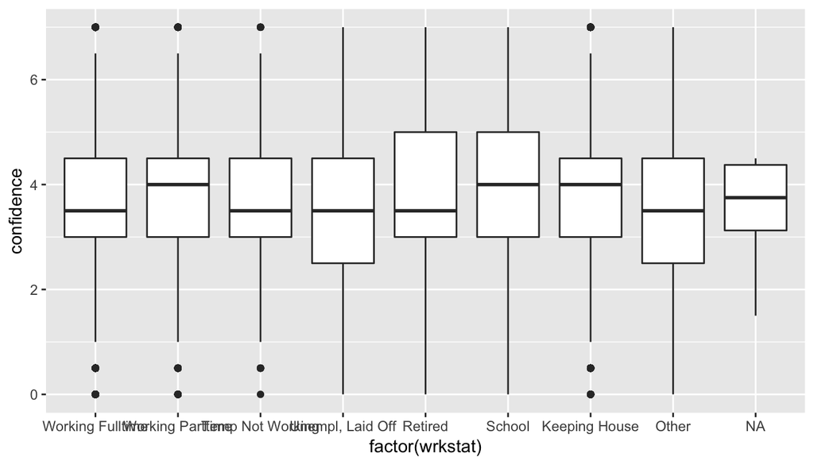

```r
ggplot(data=gss, aes(x=factor(wrkstat), y=confidence)) + geom_boxplot()
```

```r
gss %>% filter(!is.na(confidence)) %>% group_by(wrkstat) %>% summarise(iqr = IQR(confidence), mean=mean(confidence), sd=sd(confidence), count=n()) %>% arrange(desc(iqr))
```

```
## # A tibble: 9 x 5
##   wrkstat            iqr  mean    sd count
##   <fct>            <dbl> <dbl> <dbl> <int>
## 1 Unempl, Laid Off  2     3.62  1.38  1076
## 2 Retired           2     3.78  1.43  3967
## 3 School            2     4.00  1.34  1005
## 4 Other             2     3.47  1.48   602
## 5 Working Fulltime  1.5   3.77  1.30 16569
## 6 Working Parttime  1.5   3.82  1.32  3359
## 7 Temp Not Working  1.5   3.68  1.34   680
## 8 Keeping House     1.5   3.83  1.34  5013
## 9 <NA>              1.25  3.5   1.14     6
```

From the graph and the summary value, we can infer that *all the working groups are nearly confidence as every one else with similar IQR and median*. But is it the case? Check out the below inference.

## Part 4: Inference

With the mean/IQR values being some close to each other, let’s do the analysis of the data by ANOVA as we have the variable wrkstat with 8 different values.

### 4.1 Hypothesis :

Ho : nothing is going on. All the mean values are equal. So all working group people are in same confidence level

Ha : Confidence level is affected by the working status

### 4.2 Conditions :

#### 4.2.1 Independence :

1.1 Since the survey is from random sampling, we can assume independence  
1.2 And the sample must be n < 10% the population

#### 4.2.2 Approxiate Normality :

Check the distributions below

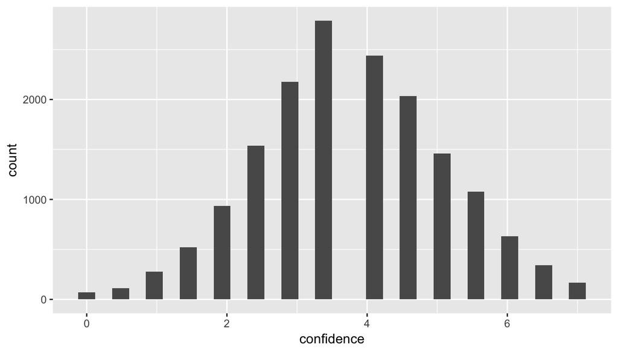

```r
ggplot(data=gss %>% filter(wrkstat=="Working Fulltime", !is.na(confidence)), aes(x=confidence)) + geom_histogram()
```

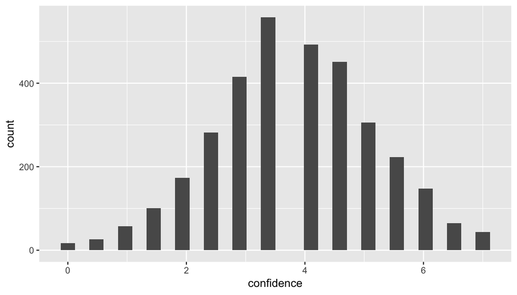

```r
ggplot(data=gss %>% filter(wrkstat=="Working Parttime", !is.na(wrkstat)), aes(x=confidence)) + geom_histogram()
```

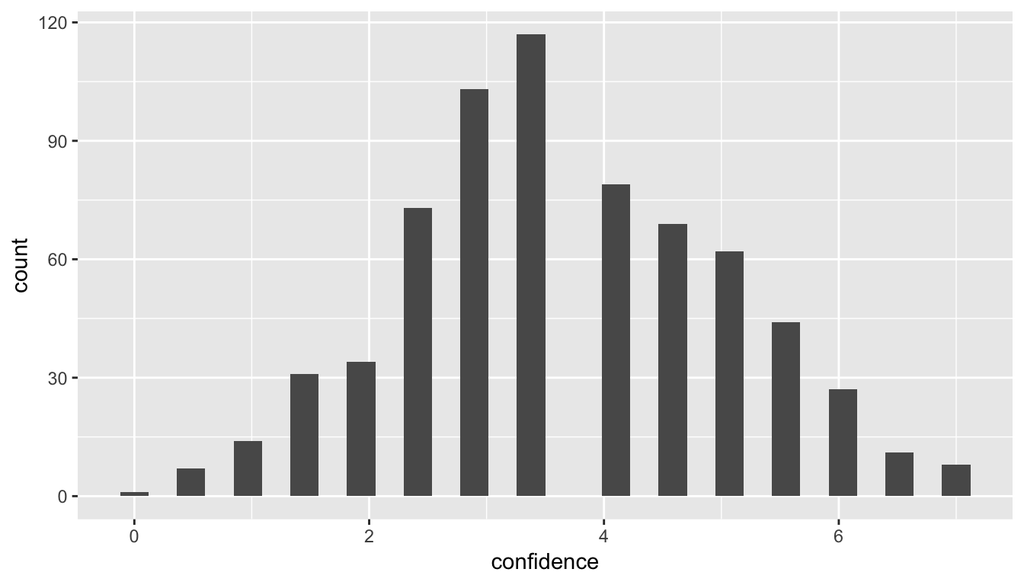

```r
ggplot(data=gss %>% filter(wrkstat=="Temp Not Working", !is.na(wrkstat)), aes(x=confidence)) + geom_histogram()
```

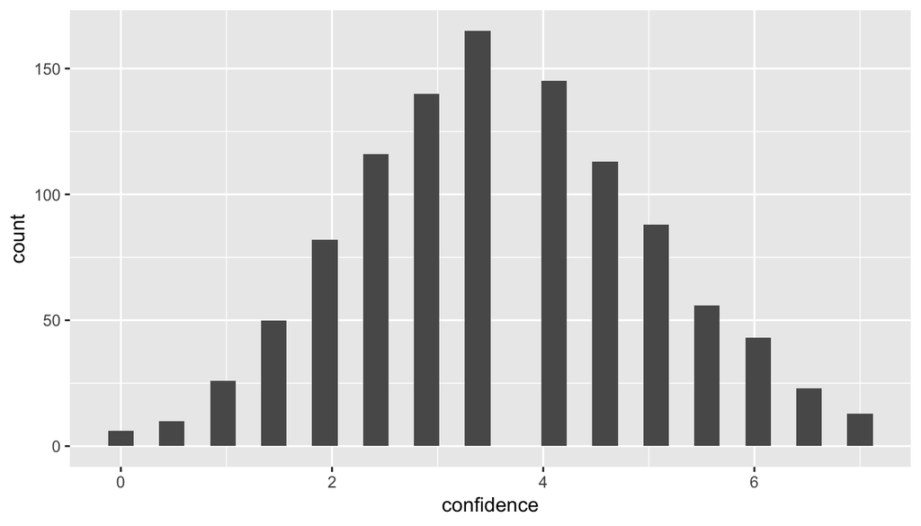

```r
ggplot(data=gss %>% filter(wrkstat=="Unempl, Laid Off", !is.na(wrkstat)), aes(x=confidence)) + geom_histogram()
```

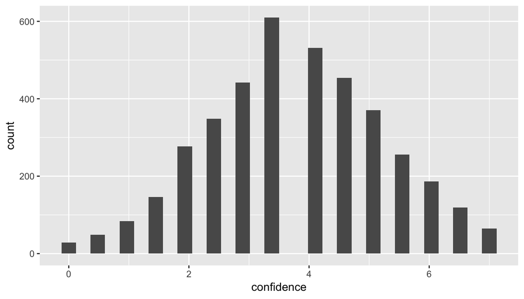

```r
ggplot(data=gss %>% filter(wrkstat=="Retired", !is.na(wrkstat)), aes(x=confidence)) + geom_histogram()
```

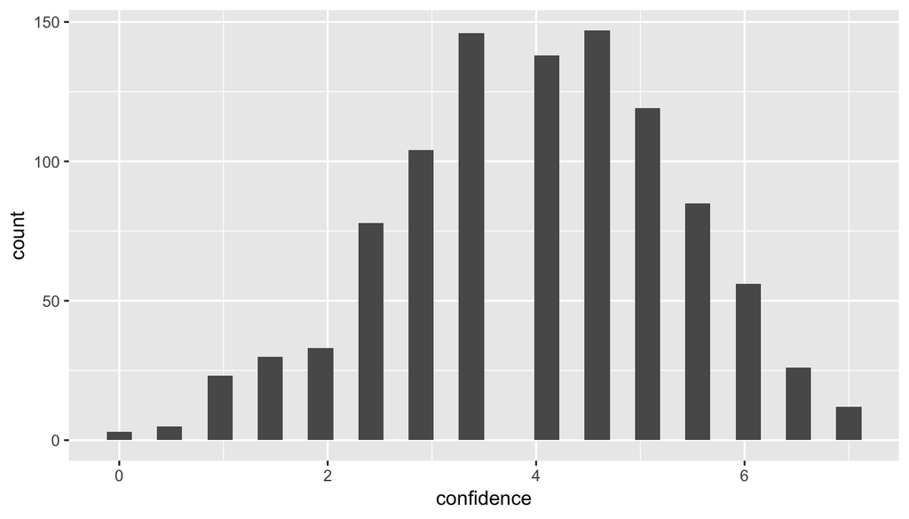

```r
ggplot(data=gss %>% filter(wrkstat=="School", !is.na(wrkstat)), aes(x=confidence)) + geom_histogram()
```

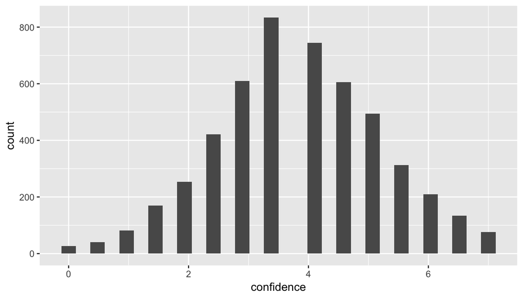

```r
ggplot(data=gss %>% filter(wrkstat=="Keeping House", !is.na(wrkstat)), aes(x=confidence)) + geom_histogram()
```

**All the distributions are nearly normal within each group**

#### 4.2.3 Equal variance

```r
var((gss %>% filter(wrkstat == "Working Fulltime" , !is.na(confidence)))$confidence)
```

```
## [1] 1.691377
```

```r
var((gss %>% filter(wrkstat == "Working Parttime" , !is.na(confidence)))$confidence)
```

```
## [1] 1.735324
```

```r
var((gss %>% filter(wrkstat == "Temp Not Working" , !is.na(confidence)))$confidence)
```

```
## [1] 1.782723
```

```r
var((gss %>% filter(wrkstat == "Unempl, Laid Off" , !is.na(confidence)))$confidence)
```

```
## [1] 1.909654
```

```r
var((gss %>% filter(wrkstat == "Retired" , !is.na(confidence)))$confidence)
```

```
## [1] 2.056441
```

```r
var((gss %>% filter(wrkstat == "School" , !is.na(confidence)))$confidence)
```

```
## [1] 1.786105
```

```r
var((gss %>% filter(wrkstat == "Keeping House" , !is.na(confidence)))$confidence)
```

```
## [1] 1.807612
```

All the values are very close to each other.

#### Hence all the conditions are satisfied

### 4.3 Method to do inference

```r
gss %>% filter(!is.na(confidence)) %>% group_by(wrkstat) %>% summarise(mean=mean(confidence), count=n())
```

```
## # A tibble: 9 x 3
##   wrkstat           mean count
##   <fct>            <dbl> <int>
## 1 Working Fulltime  3.77 16569
## 2 Working Parttime  3.82  3359
## 3 Temp Not Working  3.68   680
## 4 Unempl, Laid Off  3.62  1076
## 5 Retired           3.78  3967
## 6 School            4.00  1005
## 7 Keeping House     3.83  5013
## 8 Other             3.47   602
## 9 <NA>              3.5      6
```

We will do the inference for Anova

```r
inference(y=confidence, x=wrkstat, data=gss %>% filter(!is.na(confidence)), type="ht", statistic = "mean", null=0, sig_level = 0.05, method="theoretical", alternative="greater")
```

```
## Response variable: numerical
## Explanatory variable: categorical (8 levels)
## n_Working Fulltime = 16569, y_bar_Working Fulltime = 3.7671, s_Working Fulltime = 1.3005
## n_Working Parttime = 3359, y_bar_Working Parttime = 3.8247, s_Working Parttime = 1.3173
## n_Temp Not Working = 680, y_bar_Temp Not Working = 3.6779, s_Temp Not Working = 1.3352
## n_Unempl, Laid Off = 1076, y_bar_Unempl, Laid Off = 3.6176, s_Unempl, Laid Off = 1.3819
## n_Retired = 3967, y_bar_Retired = 3.7779, s_Retired = 1.434
## n_School = 1005, y_bar_School = 3.9995, s_School = 1.3365
## n_Keeping House = 5013, y_bar_Keeping House = 3.8336, s_Keeping House = 1.3445
## n_Other = 602, y_bar_Other = 3.4693, s_Other = 1.4765
##
## ANOVA:
##              df     Sum_Sq Mean_Sq       F  p_value
## wrkstat       7   165.9201 23.7029 13.3153 < 0.0001
## Residuals 32263 57432.3299  1.7801
## Total     32270   57598.25
##
## Pairwise tests - t tests with pooled SD:
## # A tibble: 28 x 3
##    group1           group2                p.value
##  * <chr>            <chr>                   <dbl>
##  1 Working Parttime Working Fulltime 0.0226
##  2 Temp Not Working Working Fulltime 0.0878
##  3 Unempl, Laid Off Working Fulltime 0.000369
##  4 Retired          Working Fulltime 0.645
##  5 School           Working Fulltime 0.0000000826
##  6 Keeping House    Working Fulltime 0.00197
##  7 Other            Working Fulltime 0.0000000752
##  8 Temp Not Working Working Parttime 0.00893
##  9 Unempl, Laid Off Working Parttime 0.00000942
## 10 Retired          Working Parttime 0.135
## # ... with 18 more rows
```

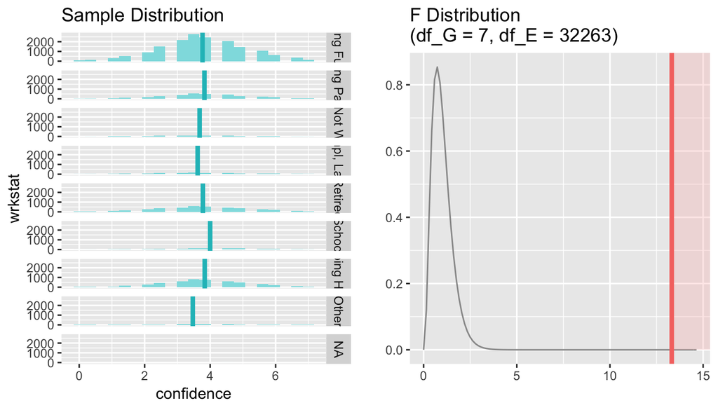

#### 4.4 Inference

With this higher F value, p-value is

```r
pf(13.3153, 7, 32263, lower.tail = FALSE);
```

```
## [1] 2.879938e-17
```

So reject the null hypothesis and conclude that *confidence level in society is affected by the work status*

### 4.5 Confidence Interval

As there is a relation between work status and confidence level, **let’s check the Confidence Interval of each work status as it could be helpful in exactly understanding the mindset of the work group**.

Let’s create some data which will contain only the data of each work status category as below

```r
work_full_data <- gss %>% filter(!is.na(confidence), wrkstat == "Working Fulltime") %>% select(confidence)
work_full_result <- inference(y=confidence, data=work_full_data, type="ci", statistic = "mean", null=0, sig_level = 0.05, method="theoretical")
```

```
## Single numerical variable
## n = 16569, y-bar = 3.7671, s = 1.3005
## 95% CI: (3.7473 , 3.7869)
```

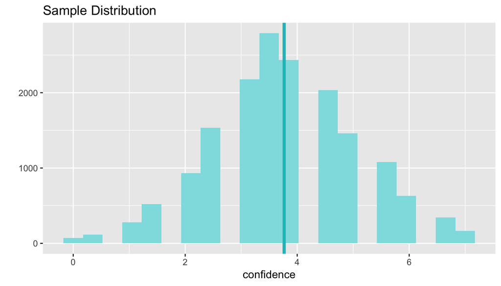

```r
work_part_data <- gss %>% filter(!is.na(confidence), wrkstat == "Working Parttime") %>% select(confidence)
work_part_data_result <- inference(y=confidence, data=work_part_data, type="ci", statistic = "mean", null=0, sig_level = 0.05, method="theoretical")
```

```
## Single numerical variable
## n = 3359, y-bar = 3.8247, s = 1.3173
## 95% CI: (3.7801 , 3.8692)
```

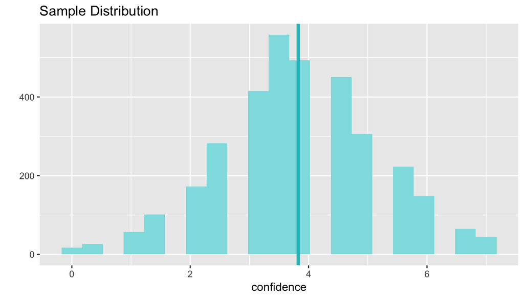

```r
temp_not_working_data <- gss %>% filter(!is.na(confidence), wrkstat == "Temp Not Working") %>% select(confidence)
temp_not_working_result <- inference(y=confidence, data=temp_not_working_data, type="ci", statistic = "mean", null=0, sig_level = 0.05, method="theoretical")
```

```
## Single numerical variable
## n = 680, y-bar = 3.6779, s = 1.3352
## 95% CI: (3.5774 , 3.7785)
```

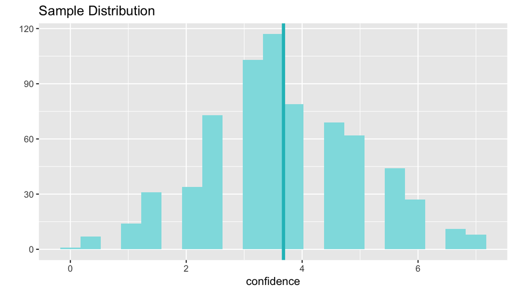

```r
unemp_data <- gss %>% filter(!is.na(confidence), wrkstat == "Unempl, Laid Off") %>% select(confidence)
unemp_result <- inference(y=confidence, data=unemp_data, type="ci", statistic = "mean", null=0, sig_level = 0.05, method="theoretical")
```

```
## Single numerical variable
## n = 1076, y-bar = 3.6176, s = 1.3819
## 95% CI: (3.5349 , 3.7002)
```

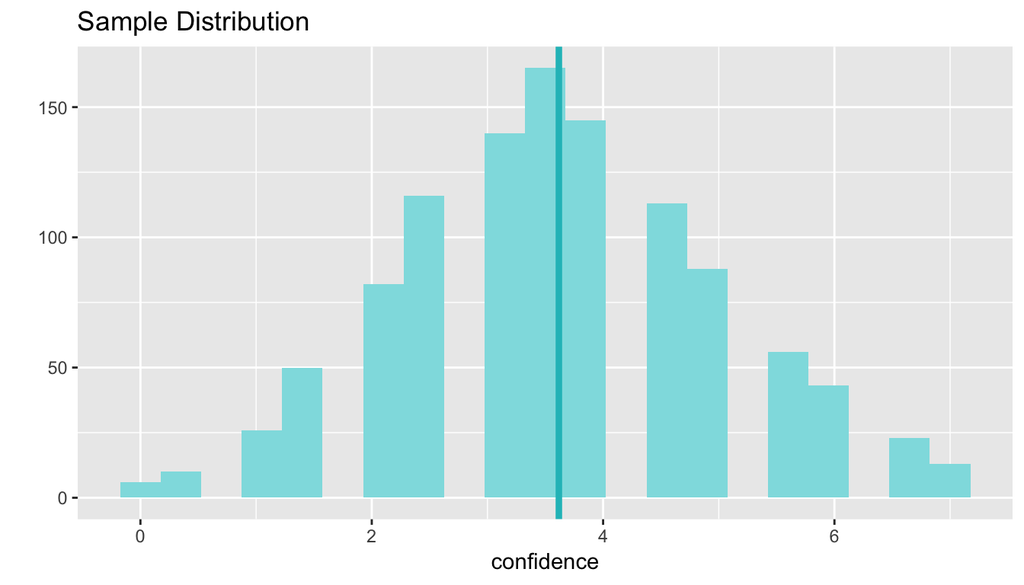

```r
retired_data <- gss %>% filter(!is.na(confidence), wrkstat == "Retired") %>% select(confidence)
retired_result <- inference(y=confidence, data=retired_data, type="ci", statistic = "mean", null=0, sig_level = 0.05, method="theoretical")
```

```
## Single numerical variable
## n = 3967, y-bar = 3.7779, s = 1.434
## 95% CI: (3.7333 , 3.8226)
```

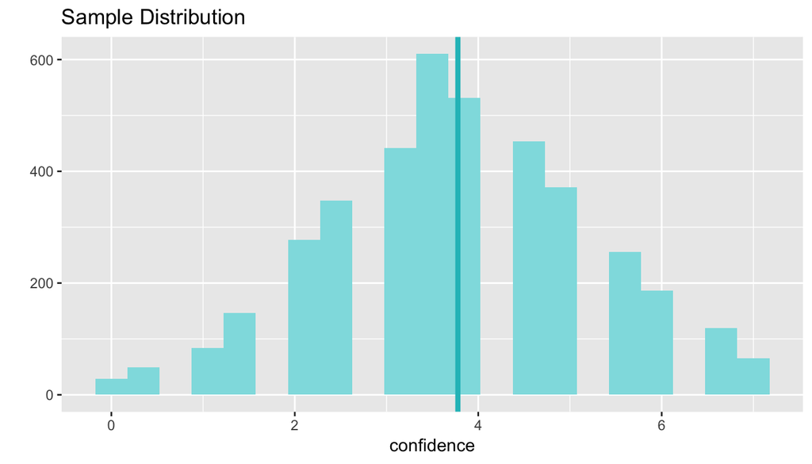

```r
school_data <- gss %>% filter(!is.na(confidence), wrkstat == "School") %>% select(confidence)
school_result <- inference(y=confidence, data=school_data, type="ci", statistic = "mean", null=0, sig_level = 0.05, method="theoretical")
```

```
## Single numerical variable
## n = 1005, y-bar = 3.9995, s = 1.3365
## 95% CI: (3.9168 , 4.0822)
```

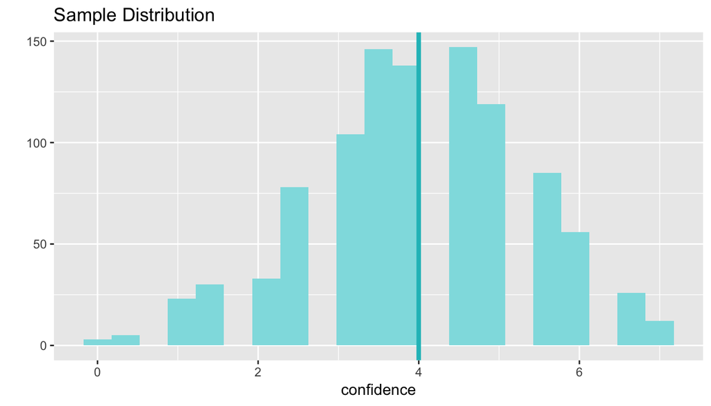

```r
keeping_house_data <- gss %>% filter(!is.na(confidence), wrkstat == "Keeping House") %>% select(confidence)
keeping_house_result <- inference(y=confidence, data=keeping_house_data, type="ci", statistic = "mean", null=0, sig_level = 0.05, method="theoretical")
```

```
## Single numerical variable
## n = 5013, y-bar = 3.8336, s = 1.3445
## 95% CI: (3.7964 , 3.8709)
```

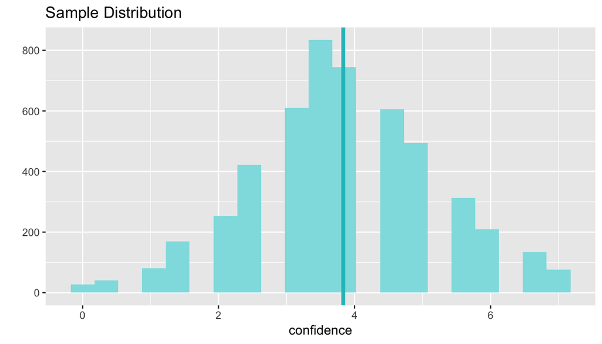

And now we compare on where each work status category stand

[figure not shown]

```r
ci_id <- c("Working Fulltime","Working Parttime", "Temp Not Working","Unempl, Laid Off", "Retired", "School", "Keeping House")

ci_bounds <- c(work_full_result$CI, work_part_data_result$CI, temp_not_working_result$CI, unemp_result$CI, retired_result$CI, school_result$CI, keeping_house_result$CI)

ci_data <- data.frame(ci_id,ci_bounds)

ggplot(data = ci_data, aes(x = ci_bounds, y = ci_id, group = ci_id)) + geom_point(size = 2) +  geom_line() + geom_vline(xintercept = (gss %>% filter(!is.na(confidence)) %>% summarise(mean=mean(confidence)))$mean, color = "darkgray")
```